# Risk Factor Analysis

## Outcome Variable

**Outcome Variable:** wasted

## Predictor Variables

**Intervention Variable:** exclfeed36

**Adjustment Set:**

- arm
- sex
- W_mage
- meducyrs
- feducyrs
- hhwealth_quart
- hfoodsec
- W_mhtcm
- vagbrth
- W_gagebrth
- W_birthwt
- W_birthlen
- W_nrooms
- W_nchldlt5
- month
- brthmon
- W_parity
- impfloor
- impsan
- safeh20
- delta_W_mage
- delta_meducyrs
- delta_feducyrs
- delta_hhwealth_quart
- delta_hfoodsec
- delta_W_mhtcm
- delta_vagbrth
- delta_W_gagebrth
- delta_W_birthwt
- delta_W_birthlen
- delta_W_nrooms
- delta_W_nchldlt5
- delta_month
- delta_brthmon
- delta_W_parity
- delta_impfloor
- delta_impsan
- delta_safeh20

## Stratifying Variables

The analysis was stratified on these variable(s):

- agecat
- studyid
- country

## Data Summary

| agecat | studyid | country | exclfeed36 | wasted | n_cell | n |
| --- | --- | --- | --- | --- | --- | --- |
| Birth | ki0047075b-MAL-ED | BANGLADESH | 1 | 0 | 48 | 230 |
| Birth | ki0047075b-MAL-ED | BANGLADESH | 1 | 1 | 10 | 230 |
| Birth | ki0047075b-MAL-ED | BANGLADESH | 0 | 0 | 143 | 230 |
| Birth | ki0047075b-MAL-ED | BANGLADESH | 0 | 1 | 29 | 230 |
| Birth | ki0047075b-MAL-ED | BRAZIL | 1 | 0 | 12 | 177 |
| Birth | ki0047075b-MAL-ED | BRAZIL | 1 | 1 | 0 | 177 |
| Birth | ki0047075b-MAL-ED | BRAZIL | 0 | 0 | 159 | 177 |
| Birth | ki0047075b-MAL-ED | BRAZIL | 0 | 1 | 6 | 177 |
| Birth | ki0047075b-MAL-ED | INDIA | 1 | 0 | 5 | 195 |
| Birth | ki0047075b-MAL-ED | INDIA | 1 | 1 | 0 | 195 |
| Birth | ki0047075b-MAL-ED | INDIA | 0 | 0 | 157 | 195 |
| Birth | ki0047075b-MAL-ED | INDIA | 0 | 1 | 33 | 195 |
| Birth | ki0047075b-MAL-ED | NEPAL | 1 | 0 | 11 | 167 |
| Birth | ki0047075b-MAL-ED | NEPAL | 1 | 1 | 0 | 167 |
| Birth | ki0047075b-MAL-ED | NEPAL | 0 | 0 | 136 | 167 |
| Birth | ki0047075b-MAL-ED | NEPAL | 0 | 1 | 20 | 167 |
| Birth | ki0047075b-MAL-ED | PERU | 1 | 0 | 15 | 266 |
| Birth | ki0047075b-MAL-ED | PERU | 1 | 1 | 0 | 266 |
| Birth | ki0047075b-MAL-ED | PERU | 0 | 0 | 245 | 266 |
| Birth | ki0047075b-MAL-ED | PERU | 0 | 1 | 6 | 266 |
| Birth | ki0047075b-MAL-ED | SOUTH AFRICA | 1 | 0 | 0 | 234 |
| Birth | ki0047075b-MAL-ED | SOUTH AFRICA | 1 | 1 | 0 | 234 |
| Birth | ki0047075b-MAL-ED | SOUTH AFRICA | 0 | 0 | 220 | 234 |
| Birth | ki0047075b-MAL-ED | SOUTH AFRICA | 0 | 1 | 14 | 234 |
| Birth | ki0047075b-MAL-ED | TANZANIA, UNITED REPUBLIC OF | 1 | 0 | 1 | 116 |
| Birth | ki0047075b-MAL-ED | TANZANIA, UNITED REPUBLIC OF | 1 | 1 | 0 | 116 |
| Birth | ki0047075b-MAL-ED | TANZANIA, UNITED REPUBLIC OF | 0 | 0 | 113 | 116 |
| Birth | ki0047075b-MAL-ED | TANZANIA, UNITED REPUBLIC OF | 0 | 1 | 2 | 116 |
| Birth | ki1000108-CMC-V-BCS-2002 | INDIA | 1 | 0 | 3 | 3 |
| Birth | ki1000108-CMC-V-BCS-2002 | INDIA | 1 | 1 | 0 | 3 |

[output cut: 150 more lines]

The following strata were considered:

- agecat: 24 months, studyid: ki0047075b-MAL-ED, country: BANGLADESH
- agecat: 24 months, studyid: ki0047075b-MAL-ED, country: BRAZIL
- agecat: 24 months, studyid: ki0047075b-MAL-ED, country: INDIA
- agecat: 24 months, studyid: ki0047075b-MAL-ED, country: NEPAL
- agecat: 24 months, studyid: ki0047075b-MAL-ED, country: PERU
- agecat: 24 months, studyid: ki0047075b-MAL-ED, country: SOUTH AFRICA
- agecat: 24 months, studyid: ki0047075b-MAL-ED, country: TANZANIA, UNITED REPUBLIC OF
- agecat: 24 months, studyid: ki1000108-CMC-V-BCS-2002, country: INDIA
- agecat: 24 months, studyid: ki1000108-IRC, country: INDIA
- agecat: 24 months, studyid: ki1017093b-PROVIDE, country: BANGLADESH
- agecat: 24 months, studyid: ki1101329-Keneba, country: GAMBIA
- agecat: 24 months, studyid: ki1113344-GMS-Nepal, country: NEPAL
- agecat: 24 months, studyid: ki1148112-LCNI-5, country: MALAWI
- agecat: 24 months, studyid: kiGH5241-JiVitA-3, country: BANGLADESH
- agecat: 24 months, studyid: kiGH5241-JiVitA-4, country: BANGLADESH
- agecat: 6 months, studyid: ki0047075b-MAL-ED, country: BANGLADESH
- agecat: 6 months, studyid: ki0047075b-MAL-ED, country: BRAZIL
- agecat: 6 months, studyid: ki0047075b-MAL-ED, country: INDIA
- agecat: 6 months, studyid: ki0047075b-MAL-ED, country: NEPAL
- agecat: 6 months, studyid: ki0047075b-MAL-ED, country: PERU
- agecat: 6 months, studyid: ki0047075b-MAL-ED, country: SOUTH AFRICA
- agecat: 6 months, studyid: ki0047075b-MAL-ED, country: TANZANIA, UNITED REPUBLIC OF
- agecat: 6 months, studyid: ki1000108-CMC-V-BCS-2002, country: INDIA
- agecat: 6 months, studyid: ki1000108-IRC, country: INDIA
- agecat: 6 months, studyid: ki1000109-EE, country: PAKISTAN
- agecat: 6 months, studyid: ki1000304b-SAS-FoodSuppl, country: INDIA
- agecat: 6 months, studyid: ki1017093b-PROVIDE, country: BANGLADESH
- agecat: 6 months, studyid: ki1101329-Keneba, country: GAMBIA
- agecat: 6 months, studyid: ki1113344-GMS-Nepal, country: NEPAL
- agecat: 6 months, studyid: ki1148112-LCNI-5, country: MALAWI
- agecat: 6 months, studyid: kiGH5241-JiVitA-3, country: BANGLADESH
- agecat: 6 months, studyid: kiGH5241-JiVitA-4, country: BANGLADESH
- agecat: Birth, studyid: ki0047075b-MAL-ED, country: BANGLADESH
- agecat: Birth, studyid: ki0047075b-MAL-ED, country: BRAZIL
- agecat: Birth, studyid: ki0047075b-MAL-ED, country: INDIA
- agecat: Birth, studyid: ki0047075b-MAL-ED, country: NEPAL
- agecat: Birth, studyid: ki0047075b-MAL-ED, country: PERU
- agecat: Birth, studyid: ki0047075b-MAL-ED, country: SOUTH AFRICA
- agecat: Birth, studyid: ki0047075b-MAL-ED, country: TANZANIA, UNITED REPUBLIC OF
- agecat: Birth, studyid: ki1000108-CMC-V-BCS-2002, country: INDIA
- agecat: Birth, studyid: ki1000108-IRC, country: INDIA
- agecat: Birth, studyid: ki1000109-EE, country: PAKISTAN
- agecat: Birth, studyid: ki1101329-Keneba, country: GAMBIA
- agecat: Birth, studyid: kiGH5241-JiVitA-3, country: BANGLADESH
- agecat: Birth, studyid: kiGH5241-JiVitA-4, country: BANGLADESH

### Dropped Strata

Some strata were dropped due to rare outcomes:

- agecat: Birth, studyid: ki0047075b-MAL-ED, country: BRAZIL
- agecat: Birth, studyid: ki0047075b-MAL-ED, country: INDIA
- agecat: Birth, studyid: ki0047075b-MAL-ED, country: NEPAL
- agecat: Birth, studyid: ki0047075b-MAL-ED, country: PERU
- agecat: Birth, studyid: ki0047075b-MAL-ED, country: SOUTH AFRICA
- agecat: Birth, studyid: ki0047075b-MAL-ED, country: TANZANIA, UNITED REPUBLIC OF
- agecat: Birth, studyid: ki1000108-CMC-V-BCS-2002, country: INDIA
- agecat: Birth, studyid: ki1000108-IRC, country: INDIA
- agecat: Birth, studyid: ki1000109-EE, country: PAKISTAN
- agecat: Birth, studyid: kiGH5241-JiVitA-4, country: BANGLADESH
- agecat: 6 months, studyid: ki0047075b-MAL-ED, country: BANGLADESH
- agecat: 6 months, studyid: ki0047075b-MAL-ED, country: BRAZIL
- agecat: 6 months, studyid: ki0047075b-MAL-ED, country: INDIA
- agecat: 6 months, studyid: ki0047075b-MAL-ED, country: NEPAL
- agecat: 6 months, studyid: ki0047075b-MAL-ED, country: PERU
- agecat: 6 months, studyid: ki0047075b-MAL-ED, country: SOUTH AFRICA
- agecat: 6 months, studyid: ki0047075b-MAL-ED, country: TANZANIA, UNITED REPUBLIC OF
- agecat: 6 months, studyid: ki1000108-CMC-V-BCS-2002, country: INDIA
- agecat: 6 months, studyid: ki1000108-IRC, country: INDIA
- agecat: 6 months, studyid: ki1000304b-SAS-FoodSuppl, country: INDIA
- agecat: 6 months, studyid: ki1017093b-PROVIDE, country: BANGLADESH
- agecat: 6 months, studyid: ki1148112-LCNI-5, country: MALAWI
- agecat: 24 months, studyid: ki0047075b-MAL-ED, country: BRAZIL
- agecat: 24 months, studyid: ki0047075b-MAL-ED, country: INDIA
- agecat: 24 months, studyid: ki0047075b-MAL-ED, country: NEPAL
- agecat: 24 months, studyid: ki0047075b-MAL-ED, country: PERU
- agecat: 24 months, studyid: ki0047075b-MAL-ED, country: SOUTH AFRICA
- agecat: 24 months, studyid: ki0047075b-MAL-ED, country: TANZANIA, UNITED REPUBLIC OF
- agecat: 24 months, studyid: ki1000108-CMC-V-BCS-2002, country: INDIA
- agecat: 24 months, studyid: ki1000108-IRC, country: INDIA
- agecat: 24 months, studyid: ki1148112-LCNI-5, country: MALAWI

## Methods Detail

We’re interested in the causal parameters $E[Y_a]$ for all values of $a \in \mathcal{A}$. These parameters represent the mean outcome if, possibly contrary to fact, we intervened to set all units to have $A=a$. Under the randomization and positivity assumptions, these are identified by the statistical parameters $\psi_a=E_W[E_{Y|A,W}(Y|A=a,W)]$. In addition, we’re interested in the mean of $Y$, $E[Y]$ under no intervention (the observed mean). We will estimate these parameters by using SuperLearner to fit the relevant likelihood factors – $E_{Y|A,W}(Y|A=a,W)$ and $p(A=a|W)$, and then updating our likelihood fit using a joint TMLE.

For unadjusted analyses ($W=\{\}$), initial likelihoods were estimated using Lrnr_glm to estimate the simple $E(Y|A)$ and Lrnr_mean to estimate $p(A)$. For adjusted analyses, a small library containing Lrnr_glmnet, Lrnr_xgboost, and Lrnr_mean was used.

Having estimated these parameters, we will then use the delta method to estimate relative risks and attributable risks relative to a prespecified baseline level of $A$.

# Results Detail

## Results Plots

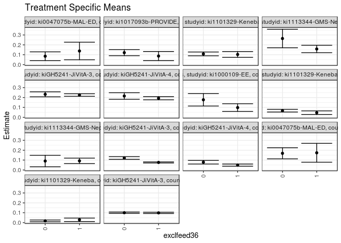

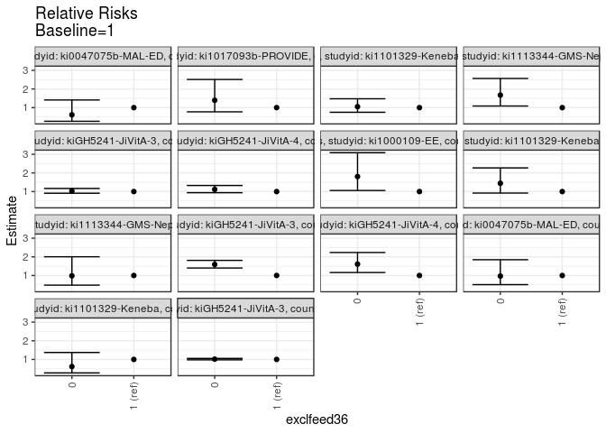

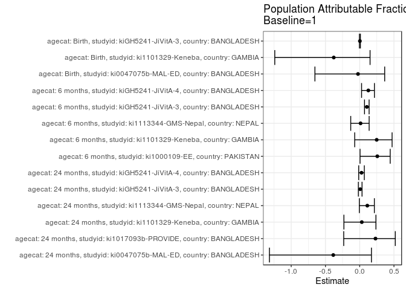

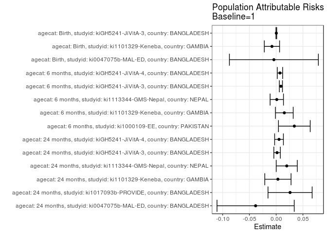

## Results Table

### Parameter: TSM

| agecat | studyid | country | intervention_level | baseline_level | estimate | ci_lower | ci_upper |
| --- | --- | --- | --- | --- | --- | --- | --- |
| Birth | ki0047075b-MAL-ED | BANGLADESH | 1 | NA | 0.1738034 | 0.0784305 | 0.2691764 |
| Birth | ki0047075b-MAL-ED | BANGLADESH | 0 | NA | 0.1685393 | 0.1124119 | 0.2246666 |
| Birth | ki1101329-Keneba | GAMBIA | 1 | NA | 0.0286765 | 0.0108062 | 0.0465467 |
| Birth | ki1101329-Keneba | GAMBIA | 0 | NA | 0.0176772 | 0.0087861 | 0.0265682 |
| Birth | kiGH5241-JiVitA-3 | BANGLADESH | 1 | NA | 0.0989326 | 0.0926611 | 0.1052042 |
| Birth | kiGH5241-JiVitA-3 | BANGLADESH | 0 | NA | 0.1004371 | 0.0934901 | 0.1073842 |
| 6 months | ki1000109-EE | PAKISTAN | 1 | NA | 0.0981286 | 0.0589553 | 0.1373018 |
| 6 months | ki1000109-EE | PAKISTAN | 0 | NA | 0.1772341 | 0.1140774 | 0.2403908 |
| 6 months | ki1101329-Keneba | GAMBIA | 1 | NA | 0.0462206 | 0.0276148 | 0.0648264 |
| 6 months | ki1101329-Keneba | GAMBIA | 0 | NA | 0.0667409 | 0.0530422 | 0.0804397 |
| 6 months | ki1113344-GMS-Nepal | NEPAL | 1 | NA | 0.0919841 | 0.0643328 | 0.1196353 |
| 6 months | ki1113344-GMS-Nepal | NEPAL | 0 | NA | 0.0903959 | 0.0320756 | 0.1487162 |
| 6 months | kiGH5241-JiVitA-3 | BANGLADESH | 1 | NA | 0.0761248 | 0.0705426 | 0.0817070 |
| 6 months | kiGH5241-JiVitA-3 | BANGLADESH | 0 | NA | 0.1212624 | 0.1078985 | 0.1346263 |
| 6 months | kiGH5241-JiVitA-4 | BANGLADESH | 1 | NA | 0.0490070 | 0.0378804 | 0.0601335 |
| 6 months | kiGH5241-JiVitA-4 | BANGLADESH | 0 | NA | 0.0788629 | 0.0603479 | 0.0973778 |
| 24 months | ki0047075b-MAL-ED | BANGLADESH | 1 | NA | 0.1379310 | 0.0489766 | 0.2268855 |
| 24 months | ki0047075b-MAL-ED | BANGLADESH | 0 | NA | 0.0849673 | 0.0406801 | 0.1292545 |
| 24 months | ki1017093b-PROVIDE | BANGLADESH | 1 | NA | 0.0868682 | 0.0409465 | 0.1327899 |
| 24 months | ki1017093b-PROVIDE | BANGLADESH | 0 | NA | 0.1211770 | 0.0901829 | 0.1521710 |
| 24 months | ki1101329-Keneba | GAMBIA | 1 | NA | 0.1028323 | 0.0735553 | 0.1321093 |
| 24 months | ki1101329-Keneba | GAMBIA | 0 | NA | 0.1082633 | 0.0887885 | 0.1277381 |
| 24 months | ki1113344-GMS-Nepal | NEPAL | 1 | NA | 0.1582333 | 0.1207313 | 0.1957353 |
| 24 months | ki1113344-GMS-Nepal | NEPAL | 0 | NA | 0.2642815 | 0.1702971 | 0.3582659 |
| 24 months | kiGH5241-JiVitA-3 | BANGLADESH | 1 | NA | 0.2253404 | 0.2122862 | 0.2383945 |
| 24 months | kiGH5241-JiVitA-3 | BANGLADESH | 0 | NA | 0.2322731 | 0.2069514 | 0.2575949 |
| 24 months | kiGH5241-JiVitA-4 | BANGLADESH | 1 | NA | 0.1929475 | 0.1768233 | 0.2090718 |
| 24 months | kiGH5241-JiVitA-4 | BANGLADESH | 0 | NA | 0.2154891 | 0.1823602 | 0.2486180 |

### Parameter: E(Y)

| agecat | studyid | country | intervention_level | baseline_level | estimate | ci_lower | ci_upper |
| --- | --- | --- | --- | --- | --- | --- | --- |
| Birth | ki0047075b-MAL-ED | BANGLADESH | NA | NA | 0.1695652 | 0.1209635 | 0.2181669 |
| Birth | ki1101329-Keneba | GAMBIA | NA | NA | 0.0207987 | 0.0127276 | 0.0288697 |
| Birth | kiGH5241-JiVitA-3 | BANGLADESH | NA | NA | 0.0992137 | 0.0929975 | 0.1054299 |
| 6 months | ki1000109-EE | PAKISTAN | NA | NA | 0.1320755 | 0.0975770 | 0.1665739 |
| 6 months | ki1101329-Keneba | GAMBIA | NA | NA | 0.0614525 | 0.0503239 | 0.0725811 |
| 6 months | ki1113344-GMS-Nepal | NEPAL | NA | NA | 0.0931559 | 0.0682937 | 0.1180181 |
| 6 months | kiGH5241-JiVitA-3 | BANGLADESH | NA | NA | 0.0849996 | 0.0797287 | 0.0902706 |
| 6 months | kiGH5241-JiVitA-4 | BANGLADESH | NA | NA | 0.0560882 | 0.0466363 | 0.0655401 |
| 24 months | ki0047075b-MAL-ED | BANGLADESH | NA | NA | 0.0995261 | 0.0590366 | 0.1400156 |
| 24 months | ki1017093b-PROVIDE | BANGLADESH | NA | NA | 0.1128472 | 0.0869854 | 0.1387090 |
| 24 months | ki1101329-Keneba | GAMBIA | NA | NA | 0.1060932 | 0.0899270 | 0.1222593 |
| 24 months | ki1113344-GMS-Nepal | NEPAL | NA | NA | 0.1780220 | 0.1428346 | 0.2132094 |
| 24 months | kiGH5241-JiVitA-3 | BANGLADESH | NA | NA | 0.2270683 | 0.2155455 | 0.2385912 |
| 24 months | kiGH5241-JiVitA-4 | BANGLADESH | NA | NA | 0.1983038 | 0.1835884 | 0.2130192 |

### Parameter: RR

| agecat | studyid | country | intervention_level | baseline_level | estimate | ci_lower | ci_upper |
| --- | --- | --- | --- | --- | --- | --- | --- |
| Birth | ki0047075b-MAL-ED | BANGLADESH | 1 | 1 | 1.0000000 | 1.0000000 | 1.000000 |
| Birth | ki0047075b-MAL-ED | BANGLADESH | 0 | 1 | 0.9697120 | 0.5094235 | 1.845893 |
| Birth | ki1101329-Keneba | GAMBIA | 1 | 1 | 1.0000000 | 1.0000000 | 1.000000 |
| Birth | ki1101329-Keneba | GAMBIA | 0 | 1 | 0.6164346 | 0.2767218 | 1.373190 |
| Birth | kiGH5241-JiVitA-3 | BANGLADESH | 1 | 1 | 1.0000000 | 1.0000000 | 1.000000 |
| Birth | kiGH5241-JiVitA-3 | BANGLADESH | 0 | 1 | 1.0152074 | 0.9780435 | 1.053783 |
| 6 months | ki1000109-EE | PAKISTAN | 1 | 1 | 1.0000000 | 1.0000000 | 1.000000 |
| 6 months | ki1000109-EE | PAKISTAN | 0 | 1 | 1.8061416 | 1.0573929 | 3.085085 |
| 6 months | ki1101329-Keneba | GAMBIA | 1 | 1 | 1.0000000 | 1.0000000 | 1.000000 |
| 6 months | ki1101329-Keneba | GAMBIA | 0 | 1 | 1.4439655 | 0.9189287 | 2.268986 |
| 6 months | ki1113344-GMS-Nepal | NEPAL | 1 | 1 | 1.0000000 | 1.0000000 | 1.000000 |
| 6 months | ki1113344-GMS-Nepal | NEPAL | 0 | 1 | 0.9827348 | 0.4819667 | 2.003806 |
| 6 months | kiGH5241-JiVitA-3 | BANGLADESH | 1 | 1 | 1.0000000 | 1.0000000 | 1.000000 |
| 6 months | kiGH5241-JiVitA-3 | BANGLADESH | 0 | 1 | 1.5929432 | 1.4012912 | 1.810807 |
| 6 months | kiGH5241-JiVitA-4 | BANGLADESH | 1 | 1 | 1.0000000 | 1.0000000 | 1.000000 |
| 6 months | kiGH5241-JiVitA-4 | BANGLADESH | 0 | 1 | 1.6092177 | 1.1593227 | 2.233702 |
| 24 months | ki0047075b-MAL-ED | BANGLADESH | 1 | 1 | 1.0000000 | 1.0000000 | 1.000000 |
| 24 months | ki0047075b-MAL-ED | BANGLADESH | 0 | 1 | 0.6160131 | 0.2688229 | 1.411606 |
| 24 months | ki1017093b-PROVIDE | BANGLADESH | 1 | 1 | 1.0000000 | 1.0000000 | 1.000000 |
| 24 months | ki1017093b-PROVIDE | BANGLADESH | 0 | 1 | 1.3949522 | 0.7752012 | 2.510176 |
| 24 months | ki1101329-Keneba | GAMBIA | 1 | 1 | 1.0000000 | 1.0000000 | 1.000000 |
| 24 months | ki1101329-Keneba | GAMBIA | 0 | 1 | 1.0528138 | 0.7518480 | 1.474257 |
| 24 months | ki1113344-GMS-Nepal | NEPAL | 1 | 1 | 1.0000000 | 1.0000000 | 1.000000 |
| 24 months | ki1113344-GMS-Nepal | NEPAL | 0 | 1 | 1.6702020 | 1.0877657 | 2.564500 |
| 24 months | kiGH5241-JiVitA-3 | BANGLADESH | 1 | 1 | 1.0000000 | 1.0000000 | 1.000000 |
| 24 months | kiGH5241-JiVitA-3 | BANGLADESH | 0 | 1 | 1.0307657 | 0.9113955 | 1.165770 |
| 24 months | kiGH5241-JiVitA-4 | BANGLADESH | 1 | 1 | 1.0000000 | 1.0000000 | 1.000000 |
| 24 months | kiGH5241-JiVitA-4 | BANGLADESH | 0 | 1 | 1.1168273 | 0.9397841 | 1.327223 |

### Parameter: PAR

| agecat | studyid | country | intervention_level | baseline_level | estimate | ci_lower | ci_upper |
| --- | --- | --- | --- | --- | --- | --- | --- |
| Birth | ki0047075b-MAL-ED | BANGLADESH | 1 | NA | -0.0042382 | -0.0873425 | 0.0788661 |
| Birth | ki1101329-Keneba | GAMBIA | 1 | NA | -0.0078778 | -0.0221420 | 0.0063864 |
| Birth | kiGH5241-JiVitA-3 | BANGLADESH | 1 | NA | 0.0002811 | -0.0004581 | 0.0010203 |
| 6 months | ki1000109-EE | PAKISTAN | 1 | NA | 0.0339469 | 0.0042773 | 0.0636165 |
| 6 months | ki1101329-Keneba | GAMBIA | 1 | NA | 0.0152319 | -0.0013637 | 0.0318275 |
| 6 months | ki1113344-GMS-Nepal | NEPAL | 1 | NA | 0.0011718 | -0.0113138 | 0.0136575 |
| 6 months | kiGH5241-JiVitA-3 | BANGLADESH | 1 | NA | 0.0088749 | 0.0059862 | 0.0117635 |
| 6 months | kiGH5241-JiVitA-4 | BANGLADESH | 1 | NA | 0.0070813 | 0.0020877 | 0.0120748 |
| 24 months | ki0047075b-MAL-ED | BANGLADESH | 1 | NA | -0.0384050 | -0.1105304 | 0.0337205 |
| 24 months | ki1017093b-PROVIDE | BANGLADESH | 1 | NA | 0.0259790 | -0.0152702 | 0.0672283 |
| 24 months | ki1101329-Keneba | GAMBIA | 1 | NA | 0.0032609 | -0.0212918 | 0.0278135 |
| 24 months | ki1113344-GMS-Nepal | NEPAL | 1 | NA | 0.0197887 | 0.0000794 | 0.0394980 |
| 24 months | kiGH5241-JiVitA-3 | BANGLADESH | 1 | NA | 0.0017280 | -0.0043635 | 0.0078194 |
| 24 months | kiGH5241-JiVitA-4 | BANGLADESH | 1 | NA | 0.0053563 | -0.0028375 | 0.0135501 |

### Parameter: PAF

| agecat | studyid | country | intervention_level | baseline_level | estimate | ci_lower | ci_upper |
| --- | --- | --- | --- | --- | --- | --- | --- |
| Birth | ki0047075b-MAL-ED | BANGLADESH | 1 | NA | -0.0249947 | -0.6537389 | 0.3647038 |
| Birth | ki1101329-Keneba | GAMBIA | 1 | NA | -0.3787640 | -1.2398031 | 0.1512691 |
| Birth | kiGH5241-JiVitA-3 | BANGLADESH | 1 | NA | 0.0028334 | -0.0046501 | 0.0102611 |
| 6 months | ki1000109-EE | PAKISTAN | 1 | NA | 0.2570265 | 0.0050560 | 0.4451852 |
| 6 months | ki1101329-Keneba | GAMBIA | 1 | NA | 0.2478649 | -0.0731278 | 0.4728426 |
| 6 months | ki1113344-GMS-Nepal | NEPAL | 1 | NA | 0.0125794 | -0.1309621 | 0.1379026 |
| 6 months | kiGH5241-JiVitA-3 | BANGLADESH | 1 | NA | 0.1044105 | 0.0702323 | 0.1373323 |
| 6 months | kiGH5241-JiVitA-4 | BANGLADESH | 1 | NA | 0.1262522 | 0.0274529 | 0.2150146 |
| 24 months | ki0047075b-MAL-ED | BANGLADESH | 1 | NA | -0.3858785 | -1.3179029 | 0.1713807 |
| 24 months | ki1017093b-PROVIDE | BANGLADESH | 1 | NA | 0.2302142 | -0.2333550 | 0.5195462 |
| 24 months | ki1101329-Keneba | GAMBIA | 1 | NA | 0.0307361 | -0.2306615 | 0.2366117 |
| 24 months | ki1113344-GMS-Nepal | NEPAL | 1 | NA | 0.1111588 | -0.0052553 | 0.2140915 |
| 24 months | kiGH5241-JiVitA-3 | BANGLADESH | 1 | NA | 0.0076099 | -0.0195867 | 0.0340810 |
| 24 months | kiGH5241-JiVitA-4 | BANGLADESH | 1 | NA | 0.0270105 | -0.0150440 | 0.0673226 |